# Geospatial Data Analysis in `R`

Load some packages.

**Note: You may need to set your working directory to the same as this file.**

```r
library(sf)
library(raster)
library(dplyr)
library(ggplot2)
library(RStoolbox) # provides fortify.raster
```

#### The `st_join` function

The `sf` library has an `st_join` function that performs a spatial join. For example, if you have a points dataset and you want to know which polygon in a polygons dataset goes with each point, then you use the `st_join` command.

```r
busstops <- st_read(dsn = "ncshape", layer = "busstopsall", quiet = T)
censusblk <- st_read(dsn = "ncshape", layer = "censusblk_swwake", quiet = T)
join <- st_join(busstops, censusblk) # rows of censusblk matched to bus stops
head(join[, 1:7]) # 'cat' is the bus stop id
```

```
## Simple feature collection with 6 features and 7 fields
## geometry type:  POINT
## dimension:      XYZ
## bbox:           xmin: 636322.6 ymin: 226374.3 xmax: 638623.8 ymax: 227160.8
## epsg (SRID):    NA
## proj4string:    +proj=lcc +lat_1=36.16666666666666 +lat_2=34.33333333333334 +lat_0=33.75 +lon_0=-79 +x_0=609601.22 +y_0=0 +datum=NAD83 +units=m +no_defs
##   cat.x ROUTES    UPDATED          STREET_1         STREET_2     CAMPUS
## 1     1    6,B 2006/11/14 William Moore Dr. Hillsborough St. Vet School
## 2     2      4 2006/11/14         Beryl Rd.             <NA>       West
## 3     3  4,6,B 2006/11/14  Hillsborough St.             <NA>      North
## 4     4      6 2006/11/14  Hillsborough St.             <NA>      North
## 5     5  4,6,B 2006/11/14  Hillsborough St.       Gorman St.      North
## 6     6    4,6 2006/11/14  Hillsborough St.     Rosemary St.      North
##   SHELTER                      geometry
## 1     Yes POINT Z (636322.6 227160.8 0)
## 2      No POINT Z (636722.1 226884.2 0)
## 3      No POINT Z (637678.9 226829.5 0)
## 4      No   POINT Z (637759.7 226832 0)
## 5      No POINT Z (638105.8 226729.4 0)
## 6      No POINT Z (638623.8 226374.3 0)
```

Try joining the lakes layer (lhs) to the swwake census blocks layer (rhs). You will get a lot of NA values where there were not matches. You can filter these out.

Functions: `st_read`, `st_join`, `is.na`, `filter`, `ggplot`, `geom_sf`

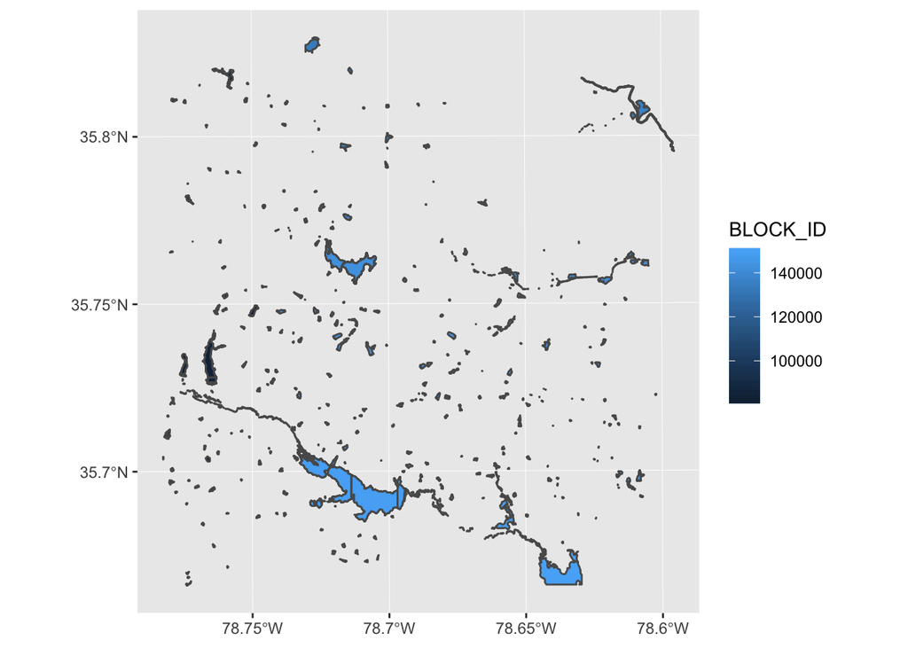

#### The `extract` function

The function `extract` in the raster package will choose pixel values in a raster based on a the points in an SpatialPoints object. The first argument of extract is a raster object. The second argument can be a wide variety of objects specifying points: 2-column matrix, 2-column data frame, a SpatialPoints object or an vector of indices. Methods are available for interpolating from neighboring cells and buffering the selection region. Here’s an example. One niggling details is that you have to strip the Z-value from the coordinates of your SpatialPoints because extract expects only x, y values, not x, y, z.

```r
zipc <- raster("ncrast/zipcodes.tif")
firest <- st_read(dsn = "ncshape", layer = "firestations", quiet = TRUE) %>% st_zm() # remove z-values
fszip <- extract(zipc, st_coordinates(firest)) # raster does not know about sf objects
res <- st_sf(LABEL = firest$LABEL, zipcode = fszip, geometry = firest$geometry) %>%
  filter(is.finite(zipcode))
print(res)
```

```
## Simple feature collection with 15 features and 2 fields
## geometry type:  POINT
## dimension:      XY
## bbox:           xmin: 630420.5 ymin: 215531.8 xmax: 644601.9 ymax: 228461.5
## epsg (SRID):    NA
## proj4string:    +proj=lcc +lat_1=36.16666666666666 +lat_2=34.33333333333334 +lat_0=33.75 +lon_0=-79 +x_0=609601.22 +y_0=0 +datum=NAD83 +units=m +no_defs
## First 10 features:
##              LABEL zipcode                  geometry
## 1      Fairview #1   27539   POINT (630420.5 215694)
## 2          Cary #2   27511 POINT (630879.2 224876.6)
## 3  Western Wake #1   27607 POINT (635775.6 228121.7)
## 4           RFD #8   27606 POINT (635940.3 225912.8)
## 5          RFD #20   27606 POINT (637386.8 222569.2)
## 6           RFD #2   27603 POINT (641437.4 221737.7)
## 7        Garner #1   27529 POINT (644588.5 217450.6)
## 8          RFD #10   27610   POINT (644598.6 221015)
## 9           RFD #3   27601 POINT (642868.3 225195.3)
## 10          RFD #5   27605 POINT (640173.9 226162.4)
```

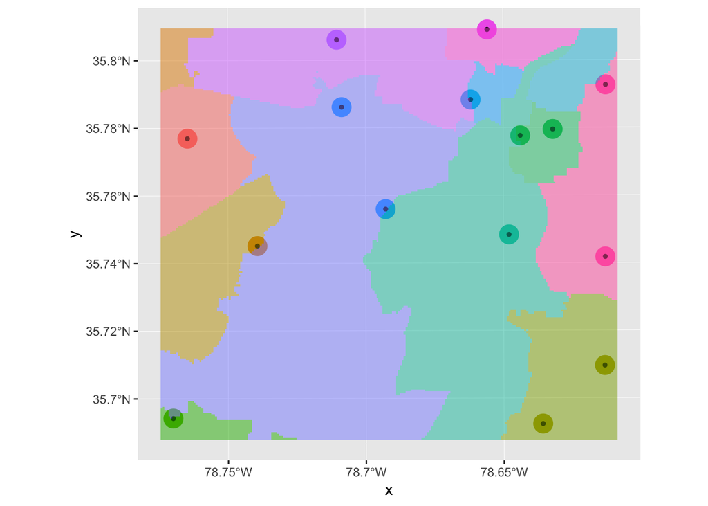

```r
ggplot() +
  geom_sf(data = res, aes(color = as.factor(zipcode), size = 2), alapha = 0.1) +
  geom_sf(data = res, aes(size = 0.5)) +
  geom_raster(data = fortify(zipc), aes(x = x, y = y, fill = as.factor(zipcodes)), alpha = 0.5) +
  guides(fill = FALSE, color = FALSE, size = FALSE)
```

#### Activity: Hospital Elevation

Use the `hospitals` point layer and the `elev_state_500m` raster to `extract` the elevation of North Carolina hospitals.

Functions: `raster`, `st_read`, `st_zm`, `extract`, `rgb`, `plot`

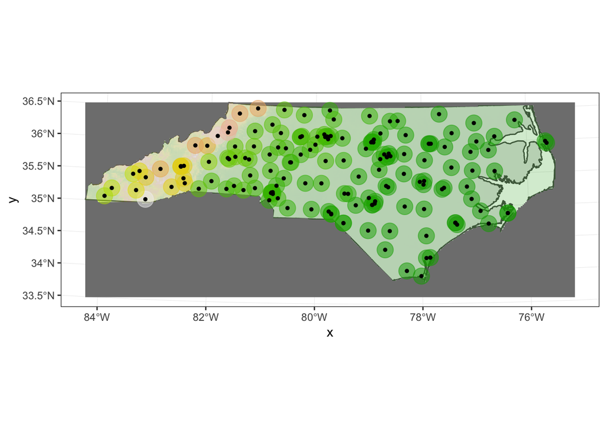